# HW2

164693 박주성

2020 4 18

# R manual

install.packages("“) library(dplyr) == require(dplyr) attach() detach() ? ?? help() setwd(”“) getwd(”")

as.datatype : 데이터 형태 변환 mode/typeof : 데이터 유형 abs(x) : 절대값 trunc(x) : 소수점 버림 round(x, n) : n의 자리에서 반올림

signif(x, n) : 유효숫자 n개 substr(x, n1, n2) : 문자열 x의 n1부터 n2까지 반환 strsplit(x, split) : 문자열 x를 split으로 분리한 값 반환

fun1 <- function(x1, x2, …){} : 사용자 정의 함수 length(x) : 데이터의 크기 확인 str(x) : 데이터의 structure을 확인 summary(x) : 요약

## 데이터 객체

x[] : 데이터 인덱싱(숫자 혹은 해당하는 곳의 이름), 조건식 사용가능, 두개 이상 원소 추출 시 c()를 사용

**벡터** : c, rep, seq, scan과 “:” 으로 생성, names(x) : 벡터의 각 원소 이름 확인

**행렬** : matrix(x, nrow, ncol, yrow, dimnames) 또는 dim(x) <- c(n1, n2) 와 같은 방법을 이용해서 생성, dimnames(x) <- list(c(행이름들), c(열이름들))

cbind, rbind 를 이용해서도 생성 가능

**배열** : array(x, dim = c(행의 수, 열의 수, 행렬의 수), dimnames), dimnames(x) <- list(c(행 이름), c(열 이름), c(행 이름)), dim(x) <- c(n1, n2, n3)

**팩터** : factor(x, labels, levels), x는 수치형 혹은 문자형 labels는 x를 순서한 후 각 원소에 범주형 자료를 대응 level는 수준의 순서를 재조정

**데이터 프레임** : data.frame(x1, x2, x3, …), read.csv(data, header = T, sep = “,”) $를 이용 가능

**리스트** : list(x1 = c(n1), x2, …), $x1 혹은 [[x1]]을 통해서 원소를 출력, 리스트 안에 들어갈 수 있는 원소의 데이터 유형은 매우 다양함

## 데이터 처리(중요!)

head(x, n = N) : x의 처음 N(default = 6)을 출력 tail(x, n = N) : xdml 마지막 N(default = 6)을 출력 rownames colnames : 행이름 열이름 출력

mean(x, na.rm = T) : 결측값을 빼고 계산 dulplicated(x) : 중복값 되는 값에 T를 표시함 => x[!duplicated(x),] 와 같은 방법을 이용해 중복값 제거

데이터 프레임에서는 $를 이용해서 새로운 항목을 추가 가능, merge(x, y, by = "") : 데이터 프레임 x, y 를 by에 지정된 변수로 병합 ?merge 활용 必

### 데이터 정렬

arrange(x, col_1, col_2) : 데이터 프레임 x를 col_1, col_2 순서대로 오름차순으로 정렬, 내림차순은 desc(col_1)과 같이 이용, 행이름 보존 안됨 dplyr

sort(x, decreasing = F) : 벡터 x를 오름차순으로 정렬, decreasing 값을 통해서 내림차순 변경 가능, 행이름을 보존한다

order(x, decreasing = F) : 벡터 x를 오름차순으로 정렬, decreasing 값을 통해서 내림차순 변경 가능, 행이름을 보존 및 원래 index를 반환

### 조건문

if (조건문) {명령문} : if안에 if를 사용가능 {}안에서 여러 명령어를 시행하려고 할 시 “;”를 통해서 구분해서 넣음

if () {} else {}, if () {} else if () {} … else () 와 같이 사용할 수 있다. ifelse(조건문, yes, no) : 맞으면 yes 시행 아니면 no 시행

swtich(x, …) : x와 일치하는 문자가 갖는 값을 반환, 업다면 NULL 출력

### 반복문

for (i in n1:n2){}, if(조건문) break/next : 조건문이 참이라고 하면 break 일 시 반복을 멈춤, next면 다음 명령을 수행하지 않고 다음 반복을 시행

while(조건문){} :조건문에 1이상의 상수나 T를 집어넣고 break를 활용해서 할 수도 있다, repeat{명령문, … if(조건문) break ….}

### 연산

as.matrix(x), data.matrix(x) : 데이터 프레임 x를 행렬로 변환, sapply(x, function) : 벡터 혹은 목록의 데이터 객체인 x에 대하여 function 실행

apply(x, margin, function) : x(수치형 행렬, 배열, 혹은 데이터 프레임)을 margin(1: 행, 2 : 열)에 따라서 function을 시행한 결과를 벡터 혹은 행렬로

lapply(x, function) : x(수치형 행렬, 배열, 혹은 데이터 프레임)의 모든 열벡터에 대하여 function을 시행한 결과를 list로 반환

tapply(x, factors, function) : 수치형 벡터 x에 대하여 factors(x와 크기가 같음)에 따라 function을 시행한 결과를 반환한다

by(x, factors, function) : tapply와 비슷하지만 결과를 list로 반환한다.

aggregate(x, by, function) : x(수치형 행렬, 배열, 혹은 데이터 프레임)을 by(x와 크기가 같음)라는 팩터별로 function을 시행한 결과 반환(df형)

aggregate(c(x1, x2, …) ~ factor1, df_name, function) : 수치형 벡터 x1, x2에 대하여 factor별 연산 결과를 데이터 프레임으로 반환

### 데이터 프레임의 재배열

t(x)(매우매우 중요) : 행렬 혹은 데이터 프레임 x를 transpose 한다. reshape패키지의 melt, cast는 별도의 검색을 이용해서 활용할 것

## 입출력

print(x, digit = n, quote = T) : 데이터 객체 x를 출력, n은 유효숫자이며, 기본적으로 ""을 붙여서 출력, quote = F 를 활용해 볼 것

cat(.., file = "“, sep =”", fill = F, append = F) (중요!) : … 출력할 개체 1개 이상을 의미, file에는 컴퓨터 디렉토리에 저장할 파일 이름을

의미하고 sep을 통해서 연결문자를 지정할 수 있다. (default = " ") 그리고 fill 을 통해서 라인별 정렬을 할것인지 정하고, append를 통해서 누적해서

출력할 것인지 아닌지를 결정한다. 위와 같은 조건들을 고려해서 ""없이 바로 출력한다. (역슬래쉬 n)활용할 것

sprintf(“%f %f %s”, height, weight, sex) %s - 문자열 혹은 수치값, %d - 정수, %f - 실수 등… ?spintf 을 활용(내용이 많음)

noquote(x) : x에 붙은 "" 또는 ’’을 제거해서 출력한다. format(x, …)이라는 출력 형식 함수도 있지만 ?format을 활용하길 권장( 내용많음)

### 파일 입출력

source(x) : R Script 파일인 x를 읽는다. 현재 디렉토리에 없을 경우 경로지정이 필요하다.

sink(“파일이름.txt”, append = F, type = c(“output”, “message”)) : R프로그램 중 output 혹은 message를 지정해서 디렉토리 내 외부파일로에 출력

sink()를 통해서 종료할 수 있다.

file(“파일명”, open = “open type”) : 디렉토리에 open type의 형식대로 읽기 혹은 쓰기가 가능한 파일을 생성한다. open type은 R내에서 참고

file.show(“파일명”) : 디렉토리에 생성된 외부 파일을 열어서 내용을 보여준다.

close(x) : file 함수에 의해 open한 외부파일인 x를 종료시킨다.

### 외부 데이터 파일 입출력

**txt** : read.table(“파일명”, header = F, sep = "“), write.table(x(행렬, df),”파일명", append = F, quote = F, row.names = T, col.names = T)

**csv** : read.csv(“파일명”, header = T), write.csv(x(행렬, df), “파일명”, append = F, row.names = T, col.names = T)

**xlsx** : read.xlsx(“파일명”, sheet = sheetIndex, colNames = T, rowNames = T), write.xlsx(파일명1(df), “파일명2”, row.names = T, col.names = T)

read.xlsx, write.xlsx 사용하기 위해서 openxlsx를 설치해야한다.

**sav***(SPSS 확장자명) : read_sav(“파일명”), write(파일명1(df), “파일명2”) / haven 패키지 필요

**sas** : read_sas(“파일명”), write(파일명1(df), “파일명2”) / haven 패키지 필요

## 그래프

plot(x, y, type = “plot-type”, …), 자세한 것은 ?plot 참고

hist(x, breaks = interval_infornamtion, freq = T, …), 자세한 것은 ?hist 참고

boxplot(x1, x2, …, horizontal = F, …), 자세한 것은 ?boxplot 참고

위는 연속형 그래프 중 대표적인 것은 뽑은 것이며, 범주형 그래프도 있다. 별도로 나중에 ggplot을 참고하길 바람.

## 기타 내용

만약 A가 정방행렬이라고 가정하면, eigen(A), det(A) 를 이용하면 편리하다.

fit <- aov(y ~ trt)

summary(aov)

fit <- lm(y ~ trt + block, data = DF) or lm(y ~ block + trt, data = DF)

anova(fit)

# R Markdown

## text

단축키 => ctrl + shift + k : knit 단축키, ctrl + alt + i : chunk 생성, ctrl + shift + / : 주석처리, 추가적으로 R에서 ctrl + shift + enter : 전체 실행

줄바꿈 => “ ”, " " : 공백 두 칸, 엔터키 두 번 등을 활용해서 줄을 바꾼다.(“ ” > 엔터 두 번 > 공백 두 번 : 간격의 크기 순)  
*기울인 글씨*, **굵은 글씨**, 윗첨자<sup>2</sup>, 취소선, 하이픈을 몇 번 사용하느냐에 따라서 크기가 달라진다 : – —, 즉시 처리하는 수식 : $A = \pi*r^{2}$

`verbatim code`

- 항목 1 (*, -, + 사용 가능하다 / 첨자 다음에 띄는 것을 주의할 것, TAB을 되도록 2번 사용하는 것이 좋다)
  - 항목 1 - 1
- 항목 2
  - 항목 2 - 1
  - 항목 2 - 2
    - 항목 2 - 2 - 1

수평선 혹은 슬라이드 멈춤(엔터키를 눌러야 한다는 것에 주의) :

> 인용블록

equation block :
$$E = mc^{2}$$

표와 관련된 것들

| 표 제목 | 두번째 제목 |
| --- | --- |
| 표 칸 | 칸 2 |
| 칸 3 | 칸 4 |

**Term 1**

Definition 1 (:의 위치가 어느 쪽으로 정렬할지 나타낸다.default : 왼쪽 정렬)

| Right | Left | Default | Center |
| --- | --- | --- | --- |
| 12 | 12 | 12 | 12 |
| 123 | 123 | 123 | 123 |
| 1 | 1 | 1 | 1 |

링크

이미지 : “![(” [] 안에 이미지 이름을 , ()안에 이미지의 위치를 입력한다.

## chunk

기본적으로 `{r}` 을 이용하거나 ctrl + alt + i 을 이용해서 만들 수 있으면 조건들을 걸면서 안에 있는 내용을 수행 수 있다.

rmarkdown을 키면 knitr::opts_chunk$set(…)이 나오는데 이는 전역 chunk들의 default 값을 변화시킬 수 있다.

### chunk option = default : explain (지정이 없다면 T F 순서대로 시행합니다.)

eval = T : 코드를 평가하고 **실행결과**를 포함한다.

```r
cat("hello")
```

```
## hello
```

```r
cat("hello")
```

echo = T : 실행결과와 함께 **코드**를 출력한다.

```r
cat("hello")
```

```
## hello
```

```
## hello
```

warning = T : 경고메시지를 출력

```r
qnorm(-0.25)
```

```
## Warning in qnorm(-0.25): NaN이 생성되었습니다
```

```
## [1] NaN
```

```r
qnorm(-0.25)
```

```
## [1] NaN
```

error = F : 오류메시지를 출력 / F 일 시 마크다운이 실행 안될 수 있어서 T의 경우만 실행합니다.

```r
#error = T
Hi!
```

```
## Error: <text>:2:3: 예기치 않은 '!'입니다
## 1: #error = T
## 2: Hi!
##      ^
```

message = T : 메시지를 출력

```r
qnorm(-0.25)
```

```
## [1] NaN
```

```r
qnorm(-0.25)
```

```
## [1] NaN
```

results = “markup” : “asis”, “hold”, “hide” 가 존재 / 차례대로 시행

```r
summary(cars)
```

```
##      speed           dist
##  Min.   : 4.0   Min.   :  2.00
##  1st Qu.:12.0   1st Qu.: 26.00
##  Median :15.0   Median : 36.00
##  Mean   :15.4   Mean   : 42.98
##  3rd Qu.:19.0   3rd Qu.: 56.00
##  Max.   :25.0   Max.   :120.00
```

```r
# 텍스형식을 값을 반환
summary(cars)
```

```
 speed           dist
```

Min. : 4.0 Min. : 2.00  
1st Qu.:12.0 1st Qu.: 26.00  
Median :15.0 Median : 36.00  
Mean :15.4 Mean : 42.98  
3rd Qu.:19.0 3rd Qu.: 56.00  
Max. :25.0 Max. :120.00

```r
# 결과를 항상 코드보다 밑에 출력
summary(cars)
```

```
##      speed           dist
##  Min.   : 4.0   Min.   :  2.00
##  1st Qu.:12.0   1st Qu.: 26.00
##  Median :15.0   Median : 36.00
##  Mean   :15.4   Mean   : 42.98
##  3rd Qu.:19.0   3rd Qu.: 56.00
##  Max.   :25.0   Max.   :120.00
```

```r
# 결과를 숨김
summary(cars)
```

include = T : chunk를 포함할지 안할지를 결정

```r
cat("Hi!")
```

```
## Hi!
```

comment = “##” : 주석문자로 출력결과에 서두를 붙인다.

```r
cat("How are you?")
```

```
## How are you?
```

```r
cat("I'm fine. And you?")
```

```
@@ I'm fine. And you?
```

fig.width = 7, fig.height = 7 : 덩어리로 생성되는 그래프의 크기를 조정한다. (단위는 inch)

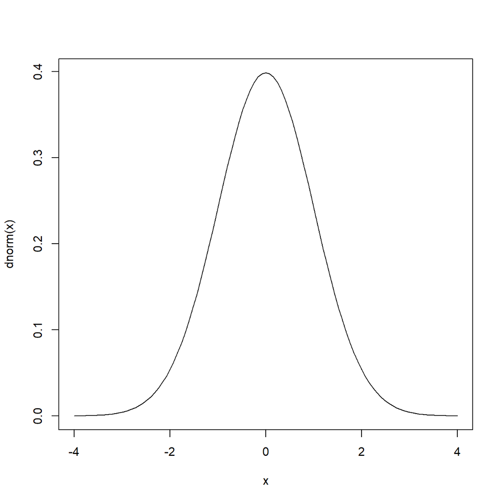

```r
curve(dnorm, -4, 4)
```

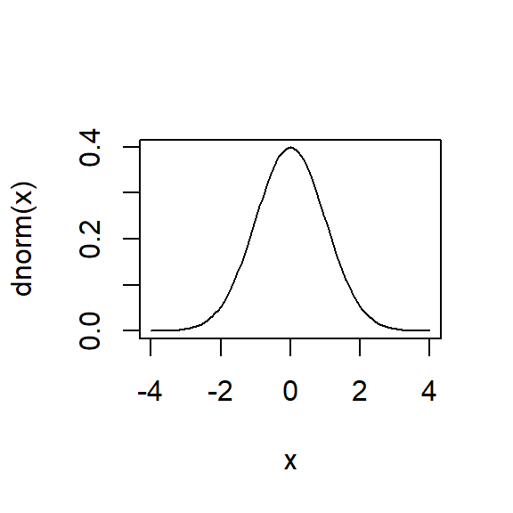

```r
curve(dnorm, -4, 4)
```

이외에도 여러가지 chunk 옵션들을 쓸 수 있다.

참고(출처 : (링크)[https://www.yan-holtz.com/PDF/Intro_RMarkDown.pdf])

#install.packages(“DT”)

```r
require(DT)
datatable(mtcars, rownames = F, filter = "top", options = list(pageLength = 5, scrollX = T))
```

| mpg | cyl | disp | hp | drat | wt | qsec | vs | am | gear | carb |
| --- | --- | --- | --- | --- | --- | --- | --- | --- | --- | --- |
| 21 | 6 | 160 | 110 | 3.9 | 2.62 | 16.46 | 0 | 1 | 4 | 4 |
| 21 | 6 | 160 | 110 | 3.9 | 2.875 | 17.02 | 0 | 1 | 4 | 4 |
| 22.8 | 4 | 108 | 93 | 3.85 | 2.32 | 18.61 | 1 | 1 | 4 | 1 |
| 21.4 | 6 | 258 | 110 | 3.08 | 3.215 | 19.44 | 1 | 0 | 3 | 1 |
| 18.7 | 8 | 360 | 175 | 3.15 | 3.44 | 17.02 | 0 | 0 | 3 | 2 |
| 18.1 | 6 | 225 | 105 | 2.76 | 3.46 | 20.22 | 1 | 0 | 3 | 1 |
| 14.3 | 8 | 360 | 245 | 3.21 | 3.57 | 15.84 | 0 | 0 | 3 | 4 |
| 24.4 | 4 | 146.7 | 62 | 3.69 | 3.19 | 20 | 1 | 0 | 4 | 2 |
| 22.8 | 4 | 140.8 | 95 | 3.92 | 3.15 | 22.9 | 1 | 0 | 4 | 2 |
| 19.2 | 6 | 167.6 | 123 | 3.92 | 3.44 | 18.3 | 1 | 0 | 4 | 4 |

[output cut: 22 more lines]